# **Proyecto análisis de datos Hotel Booking**

Equipo:

- Alex Muñoz
- Giselle Acuña
- Bastián Barrientos

Fecha de entrega: 29-06-2022

*Video presentación*: https://www.youtube.com/watch?v=aWp-dJV8cf4

# **Correcciones al hito 1**

- Se cambió la motivación del problema para que se asemejara a como estaba en la presentación del hito 1.
- Se cambiaron y reformularon las preguntas para que sean abordables con los conceptos vistos en clases.
- En la exploración de datos, los gráficos y medidas se realizaron para que vayan relacionadas con las preguntas planteadas.
- Se pusieron como referencias los códigos fuente utilizados para no incurrir en plagio y que el hito sea lo más reproducible posible.

# **Correcciones al hito 2**

- Se completó más la propuesta experimental y resultado preliminar para la pregunta 1.
- Se arreglo la redacción en algunas partes del reporte.

# **Problema y motivación del problema**

El equipo de T4 fue contratado para realizar el análisis de un set de datos de reservas hoteleras [3], del cual se espera obtener la mayor información sobre el comportamiento de los huéspedes que reservan y cómo optimizar la ganancia de los hoteles.

La motivación de nuestro equipo detrás de este proyecto, es poder tener una mejor comprensión en cuanto al funcionamiento detrás de la industria hotelera desde la reserva.

En cuanto a la estructuración trabajamos con dos datasets con la misma estructura, el primer dataset corresponde a un resort hotel y el segundo dataset corresponde a un city hotel. Las dimensiones de estos 2 datasets son: Resort Hotel (H1) - 40,060 observaciones City Hotel (H2) - 79,330 observaciones lo que nos da un total de 119,390 observaciones y 36 columnas. Cada observación representa una reserva de hotel realizada entre el 01 de Julio del 2015 y el 31 de Agosto del 2017.

Como es sabido, el análisis descriptivo puede ser aplicado para entender de manera profunda patrones, tendencias y anomalías en los datos. Por lo que el análisis de este dataset en particular nos permite encontrar respuestas a diferentes interrogantes, como la predicción de la cancelación de la reserva, la segmentación de los clientes, la satisfacción de los clientes y la estacionalidad.

# **Preprocesamiento de datos**

```python
import pandas as pd
import matplotlib.pyplot as plt

#Se obtienen los datos de reserva de hotel desde un Github personal.
datos_reserva_hotel = pd.read_csv ('https://gitlab.com/s2c52/ingenieria-de-datos-t4/-/raw/main/hotel_booking.csv', sep=',')
datos_reserva_hotel.head()
```

|  | hotel | is_canceled | lead_time | arrival_date_year | arrival_date_month | arrival_date_week_number | arrival_date_day_of_month | stays_in_weekend_nights | stays_in_week_nights | adults | ... | customer_type | adr | required_car_parking_spaces | total_of_special_requests | reservation_status | reservation_status_date | name | email | phone-number | credit_card |
| --- | --- | --- | --- | --- | --- | --- | --- | --- | --- | --- | --- | --- | --- | --- | --- | --- | --- | --- | --- | --- | --- |
| 0 | Resort Hotel | 0 | 342 | 2015 | July | 27 | 1 | 0 | 0 | 2 | ... | Transient | 0.0 | 0 | 0 | Check-Out | 2015-07-01 | Ernest Barnes | Ernest.Barnes31@outlook.com | 669-792-1661 | ************4322 |
| 1 | Resort Hotel | 0 | 737 | 2015 | July | 27 | 1 | 0 | 0 | 2 | ... | Transient | 0.0 | 0 | 0 | Check-Out | 2015-07-01 | Andrea Baker | Andrea_Baker94@aol.com | 858-637-6955 | ************9157 |
| 2 | Resort Hotel | 0 | 7 | 2015 | July | 27 | 1 | 0 | 1 | 1 | ... | Transient | 75.0 | 0 | 0 | Check-Out | 2015-07-02 | Rebecca Parker | Rebecca_Parker@comcast.net | 652-885-2745 | ************3734 |
| 3 | Resort Hotel | 0 | 13 | 2015 | July | 27 | 1 | 0 | 1 | 1 | ... | Transient | 75.0 | 0 | 0 | Check-Out | 2015-07-02 | Laura Murray | Laura_M@gmail.com | 364-656-8427 | ************5677 |
| 4 | Resort Hotel | 0 | 14 | 2015 | July | 27 | 1 | 0 | 2 | 2 | ... | Transient | 98.0 | 0 | 1 | Check-Out | 2015-07-03 | Linda Hines | LHines@verizon.com | 713-226-5883 | ************5498 |

5 rows × 36 columns

```python
#Se cuentan los valores vacíos en cada columna del dataset [2] y se imprimen los resultados.
cantidad_nan = datos_reserva_hotel.isna().sum()
print ('Columnas con valores NaN:')
print(cantidad_nan)
```

```
Columnas con valores NaN:
hotel                                  0
is_canceled                            0
lead_time                              0
arrival_date_year                      0
arrival_date_month                     0
arrival_date_week_number               0
arrival_date_day_of_month              0
stays_in_weekend_nights                0
stays_in_week_nights                   0
adults                                 0
children                               4
babies                                 0
meal                                   0
country                              488
market_segment                         0
distribution_channel                   0
is_repeated_guest                      0
previous_cancellations                 0
previous_bookings_not_canceled         0
reserved_room_type                     0
assigned_room_type                     0
booking_changes                        0
deposit_type                           0
agent                              16340
company                           112593
days_in_waiting_list                   0
customer_type                          0
adr                                    0
required_car_parking_spaces            0
total_of_special_requests              0
reservation_status                     0
reservation_status_date                0
name                                   0
email                                  0
phone-number                           0
credit_card                            0
dtype: int64
```

```python
#Se calcula e imprime el porcentaje de valores vacíos en cada columna del dataset [4].
porcentaje_nan = cantidad_nan / len(datos_reserva_hotel)
porcentaje_nan
```

```
hotel                             0.000000
is_canceled                       0.000000
lead_time                         0.000000
arrival_date_year                 0.000000
arrival_date_month                0.000000
arrival_date_week_number          0.000000
arrival_date_day_of_month         0.000000
stays_in_weekend_nights           0.000000
stays_in_week_nights              0.000000
adults                            0.000000
children                          0.000034
babies                            0.000000
meal                              0.000000
country                           0.004087
market_segment                    0.000000
distribution_channel              0.000000
is_repeated_guest                 0.000000
previous_cancellations            0.000000
previous_bookings_not_canceled    0.000000
reserved_room_type                0.000000
assigned_room_type                0.000000
booking_changes                   0.000000
deposit_type                      0.000000
agent                             0.136862
company                           0.943069
days_in_waiting_list              0.000000
customer_type                     0.000000
adr                               0.000000
required_car_parking_spaces       0.000000
total_of_special_requests         0.000000
reservation_status                0.000000
reservation_status_date           0.000000
name                              0.000000
email                             0.000000
phone-number                      0.000000
credit_card                       0.000000
dtype: float64
```

```python
#Al ver los porcentajes, se llega a la conclusión que lo mejor es eliminar la columna company y agent porque tienen un porcentaje relativamente alto de valores vacíos [5].
company_aux = datos_reserva_hotel.pop("company")
agent_aux = datos_reserva_hotel.pop("agent")
```

```python
#Se reemplazan los valores vacíos en las columnas country y children del dataset con cero [1], debido a su bajo porcentaje de valores vacíos no tendrá un impacto tan grande.
datos_reserva_hotel_limpios = datos_reserva_hotel.fillna(0)

#Se imprimen una nueva cantidad de valores vacíos [2] para revisar el resultado.
nueva_cantidad_nan = datos_reserva_hotel_limpios.isna().sum()
print ('Nuevas columnas sin valores NaN:')
print(nueva_cantidad_nan)
```

```
Nuevas columnas sin valores NaN:
hotel                             0
is_canceled                       0
lead_time                         0
arrival_date_year                 0
arrival_date_month                0
arrival_date_week_number          0
arrival_date_day_of_month         0
stays_in_weekend_nights           0
stays_in_week_nights              0
adults                            0
children                          0
babies                            0
meal                              0
country                           0
market_segment                    0
distribution_channel              0
is_repeated_guest                 0
previous_cancellations            0
previous_bookings_not_canceled    0
reserved_room_type                0
assigned_room_type                0
booking_changes                   0
deposit_type                      0
days_in_waiting_list              0
customer_type                     0
adr                               0
required_car_parking_spaces       0
total_of_special_requests         0
reservation_status                0
reservation_status_date           0
name                              0
email                             0
phone-number                      0
credit_card                       0
dtype: int64
```

# **Exploración de datos**

La exploración de datos se hará para identificar que tipo de cliente que traerá más o menos beneficios a los hoteles.

En cuanto a los campos que pueden resultar de interés, hay columnas asociadas a los tipos de personas que reservan, la tarifa media diaria, el tiempo de llegada y la cancelación de la reserva.

Campos de interés:

- adr: Tarifa media diaria (calculada dividiendo la suma de todas las transacciones de alojamiento por el número total de noches de estancia).
- adults: Número de adultos en la reserva.
- children: Número de niños en la reserva.
- babies: Número de bebés en la reserva.
- is_canceled: Valor que indica si la reserva fue cancelada (1) o no (0).
- lead_time: Número de días transcurridos entre la fecha de entrada de la reserva en el PMS y la fecha de llegada.

```python
import numpy as np
#Se busca crear nuevos campos a partir de algunos existentes en el dataset [6], esto es con el fin de diferenciar el tipo de cliente que hace una reserva en los hoteles.

#Se establecen las condiciones para crear el campo adult_only a partir de los campos children y babies.
condiciones_adultos = [
    (datos_reserva_hotel_limpios['children'] == 0) & (datos_reserva_hotel_limpios['babies'] == 0),
    (datos_reserva_hotel_limpios['children'] != 0) | (datos_reserva_hotel_limpios['babies'] != 0)
]

#Se establecen las condiciones para crear el campo adultWithBabies a partir de los campos children y babies.
condiciones_bebes = [
    (datos_reserva_hotel_limpios['children'] == 0) & (datos_reserva_hotel_limpios['babies'] > 0),
    (datos_reserva_hotel_limpios['children'] != 0) | (datos_reserva_hotel_limpios['babies'] == 0)
]

#Se establecen las condiciones para crear el campo adultWithChildrens a partir de los campos children y babies.
condiciones_ninios = [
    (datos_reserva_hotel_limpios['children'] > 0) & (datos_reserva_hotel_limpios['babies'] == 0),
    (datos_reserva_hotel_limpios['children'] == 0) | (datos_reserva_hotel_limpios['babies'] != 0)
]

#Se establecen las condiciones para crear el campo AdultWithSons a partir de los campos children y babies.
condiciones_hijos = [
    (datos_reserva_hotel_limpios['children'] > 0) & (datos_reserva_hotel_limpios['babies'] > 0),
    (datos_reserva_hotel_limpios['children'] == 0) & (datos_reserva_hotel_limpios['babies'] == 0)
]

#Se definen los valores que tomarán las nuevas columnas.
valores = [1,0]

#Se crean los nuevos campos.
datos_reserva_hotel_limpios['adult_only'] = np.select(condiciones_adultos, valores)
datos_reserva_hotel_limpios['adultWithBabies'] = np.select(condiciones_bebes, valores)
datos_reserva_hotel_limpios['adultWithChildrens'] = np.select(condiciones_ninios, valores)
datos_reserva_hotel_limpios['AdultWithSons'] = np.select(condiciones_hijos, valores)

#Se imprime una muestra de los campos resultantes y de las columnas involucradas en su creación.
datos_reserva_hotel_limpios[['adults', 'children', 'babies', 'adult_only', 'adultWithBabies', 'adultWithChildrens', 'AdultWithSons']].head()
```

|  | adults | children | babies | adult_only | adultWithBabies | adultWithChildrens | AdultWithSons |
| --- | --- | --- | --- | --- | --- | --- | --- |
| 0 | 2 | 0.0 | 0 | 1 | 0 | 0 | 0 |
| 1 | 2 | 0.0 | 0 | 1 | 0 | 0 | 0 |
| 2 | 1 | 0.0 | 0 | 1 | 0 | 0 | 0 |
| 3 | 1 | 0.0 | 0 | 1 | 0 | 0 | 0 |
| 4 | 2 | 0.0 | 0 | 1 | 0 | 0 | 0 |

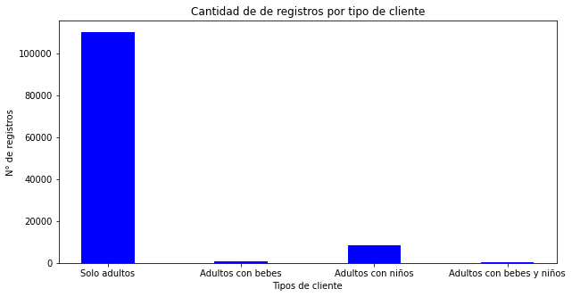

```python
import matplotlib.pyplot as plt

#Se hace un gráfico de barras para visualizar el total de registros por cada tipo de cliente [9].

#Se obtiene el total de registros en el dataset para cada tipo de cliente.
total_solo_adultos = datos_reserva_hotel_limpios['adult_only'].sum()
total_adultos_bebes = datos_reserva_hotel_limpios['adultWithBabies'].sum()
total_adultos_ninios = datos_reserva_hotel_limpios['adultWithChildrens'].sum()
total_adultos_hijos = datos_reserva_hotel_limpios['AdultWithSons'].sum()

#Se crea un nuevo dataset con el registros por tipo de cliente.
datos = {'Solo adultos':total_solo_adultos, 'Adultos con bebes':total_adultos_bebes, 'Adultos con niños':total_adultos_ninios, 'Adultos con bebes y niños':total_adultos_hijos}
tipo_cliente  = list(datos.keys())
total_tipo_cliente = list(datos.values())

fig = plt.figure(figsize = (10, 5))

#Se crea el gráfico de barras.
plt.bar(tipo_cliente, total_tipo_cliente, color ='blue',width = 0.4)

plt.xlabel("Tipos de cliente")
plt.ylabel("N° de registros")
plt.title("Cantidad de de registros por tipo de cliente")
plt.show()
```

A partir del gráfico observado, se puede ver que la mayoría de las reservas se componen por adultos solamente, siendo este el tipo de cliente más repetido. A continuación, se verá que tipo de cliente beneficia más a los hoteles.

```python
#Se calcula el promedio de la tarifa diaria por cada categoría de cliente [7].
prom_tarifa_solo_adultos = datos_reserva_hotel_limpios.loc[datos_reserva_hotel_limpios['adult_only'] == 1, 'adr'].mean()
prom_tarifa_adultos_bebes = datos_reserva_hotel_limpios.loc[datos_reserva_hotel_limpios['adultWithBabies'] == 1, 'adr'].mean()
prom_tarifa_adultos_ninios = datos_reserva_hotel_limpios.loc[datos_reserva_hotel_limpios['adultWithChildrens'] == 1, 'adr'].mean()
prom_tarifa_adultos_hijos = datos_reserva_hotel_limpios.loc[datos_reserva_hotel_limpios['AdultWithSons'] == 1, 'adr'].mean()

print('Promedio de tarifa diaria solo adultos: '+str(prom_tarifa_solo_adultos))
print('Promedio de tarifa diaria adultos con bebes: '+str(prom_tarifa_adultos_bebes))
print('Promedio de tarifa diaria adultos con niños: '+str(prom_tarifa_adultos_ninios))
print('Promedio de tarifa diaria adultos con bebes y niños: '+str(prom_tarifa_adultos_hijos))
```

```
Promedio de tarifa diaria solo adultos: 97.37077704483092
Promedio de tarifa diaria adultos con bebes: 112.22223719676549
Promedio de tarifa diaria adultos con niños: 158.20546405228757
Promedio de tarifa diaria adultos con bebes y niños: 152.09565714285714
```

A partir de los resultados, podemos concluir que los adultos acompañados por niños tienen una tarifa diaria superior que cuando van adultos solamente, los hoteles probablemente deberían atraer más adultos acompañados de niños y/o bebés, teniendo en cuenta además que la mayoría de las reservas son solo para adultos.

```python
#Se calcula el promedio de días de llegada por cada categoría de cliente [7].
prom_tiempo_solo_adultos = datos_reserva_hotel_limpios.loc[datos_reserva_hotel_limpios['adult_only'] == 1, 'lead_time'].mean()
prom_tiempo_adultos_bebes = datos_reserva_hotel_limpios.loc[datos_reserva_hotel_limpios['adultWithBabies'] == 1, 'lead_time'].mean()
prom_tiempo_adultos_ninios = datos_reserva_hotel_limpios.loc[datos_reserva_hotel_limpios['adultWithChildrens'] == 1, 'lead_time'].mean()
prom_tiempo_adultos_hijos = datos_reserva_hotel_limpios.loc[datos_reserva_hotel_limpios['AdultWithSons'] == 1, 'lead_time'].mean()

print('Promedio de dias de llegada solo adultos: '+str(prom_tiempo_solo_adultos))
print('Promedio de dias de llegada adultos con bebes: '+str(prom_tiempo_adultos_bebes))
print('Promedio de dias de llegada adultos con niños: '+str(prom_tiempo_adultos_ninios))
print('Promedio de dias de llegada adultos con bebes y niños: '+str(prom_tiempo_adultos_hijos))
```

```
Promedio de dias de llegada solo adultos: 105.3226026277054
Promedio de dias de llegada adultos con bebes: 79.75471698113208
Promedio de dias de llegada adultos con niños: 89.73761140819964
Promedio de dias de llegada adultos con bebes y niños: 68.61714285714285
```

A partir de los resultados, podemos concluir que cuando hay una reserva solamente para adultos suele haber un tiempo de llegada superior a cuando van acompañados de niños y/o bebés. Por lo cual, nuevamente es conveniente para los hoteles atraer adultos acompañados de niños y/o bebés.

```python
#Se busca un nuevo campo a partir de algunos existentes en el dataset [6], esto es con el fin de diferenciar el futuro gráfico de cajas y bigotes por tipo de cliente.

#Se establecen las condiciones para crear el campo client_type a partir de los campos adult_only, adultWithBabies, adultWithChildrens y AdultWithSons.
condiciones_tipo_cliente = [
    (datos_reserva_hotel_limpios['adult_only'] == 1),
    (datos_reserva_hotel_limpios['adultWithBabies'] == 1),
    (datos_reserva_hotel_limpios['adultWithChildrens'] == 1),
    (datos_reserva_hotel_limpios['AdultWithSons'] == 1)
]

#Se definen los valores que tomará el nuevo campo.
valores_tipo_cliente = ['Solo adultos', 'Con bebes', 'Con niños', 'Con bebes y niños']

#Se crea el nuevo campo client_type.
datos_reserva_hotel_limpios['client_type'] = np.select(condiciones_tipo_cliente, valores_tipo_cliente)
```

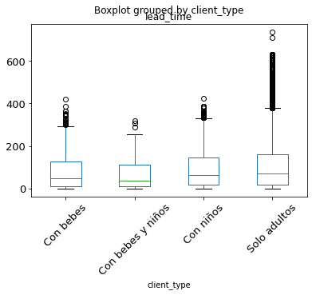

```python
#Se crea el gráfico de cajas y bigotes del tiempo de llegada de cada tipo de cliente una vez hecha la reserva [8].
boxplot = datos_reserva_hotel_limpios.boxplot(column=['lead_time'],by="client_type",grid=False, rot=45, fontsize=13)
boxplot.plot()

plt.show()
```

A partir de estos resultados, se pueden apreciar los valores atipicos de cada tipo de cliente. Siendo las reservas hechas solamente por adultos las que tienen una mayor cantidad de valores atípicos y con una medida más alejada de la media. Por lo cual, se puede concluir que la gran cantidad de outliers existentes pudo haber afectado la veracidad del promedio, dándole un valor relativamente alto al tipo de cliente: solo adultos.

```python
#También podemos ver la correlación del campo is_canceled con los demás campos, de esta manera podemos ver que atributos influyen más en la cancelación.
datos_reserva_hotel_limpios.corr()['is_canceled'].sort_values()
```

```
total_of_special_requests        -0.234658
required_car_parking_spaces      -0.195498
booking_changes                  -0.144381
is_repeated_guest                -0.084793
previous_bookings_not_canceled   -0.057358
babies                           -0.032491
adultWithBabies                  -0.031306
AdultWithSons                    -0.013974
arrival_date_day_of_month        -0.006130
stays_in_weekend_nights          -0.001791
adultWithChildrens               -0.001698
children                          0.005036
arrival_date_week_number          0.008148
adult_only                        0.012776
arrival_date_year                 0.016660
stays_in_week_nights              0.024765
adr                               0.047557
days_in_waiting_list              0.054186
adults                            0.060017
previous_cancellations            0.110133
lead_time                         0.293123
is_canceled                       1.000000
Name: is_canceled, dtype: float64
```

# **Preguntas y problemas**

- ¿De qué manera se podría predecir la cancelación de una reserva por parte del cliente a partir de los datos disponibles? ¿Qué beneficios aportará a los hoteles esta predicción?
- ¿Qué tipo de cliente (adultos, adultos con niños, adultos con bebés, etc) produce una mayor tarifa diaria para los hoteles (campo adr)? ¿Qué beneficios aportaría a los hoteles esta información?
- ¿Qué tipo de cliente tiene un tiempo de llegada mayor luego de realizar la reserva a un hotel? ¿Sería de utilidad esta información para los hoteles?
- ¿A qué tipo de cliente deberían dirigirse los hoteles para mejorar sus ingresos?

# **Propuesta experimental**

Para responder la pregunta orientada a la predicción de si una reserva será cancelada, se implementará un modelo de clasificación supervisada. Se hará de esta manera ya que el objetivo es que el modelo aprenda los patrones presentes en los datos, con el fin de predecir la cancelación de reserva en distintos datasets.

En cuanto a los modelos que se probarán en el dataset, se optará por:

- Árbol de decisión: Este modelo tiene la ventaja de que es relativamente fácil de entender e interpretar, además puede analizar atributos cualitativos y cuantitativos para lograr la clasificación. En el presente caso, se analizarán los datos cuantitativos del dataset solamente.
- Naïve Bayes: Este modelo suele ser usado para realizar clasificaciones binarias, o sea de 2 clases posibles. En este caso, se opta por utilizar este modelo debido a que dentro de sus características se encuentra su robustez ante los valores ruidosos y ante atributos irrelevantes. Siendo estas 2 características presentes en algunos campos del dataset, como el ruido que hay en la columna lead y los valores irrelevantes al ser reemplazados por cero en la limpieza.
- SVM: El modelo Support Vector Machines es utilizado para clasificación, regresión y detección de valores atípicos. Se usará en este dataset porque es eficaz cuando hay grandes dimensiones y es eficiente en memoria.

Aunque se pudo haber probado el algoritmo KNN, se optó por ignorarlo ya que funciona mal cuando hay una alta dimensionalidad en el dataset y es más costoso en potencia y tiempo. Cabe destacar que se probó el algoritmo KNN y se cayó el entorno Google Colab por falta de memoria RAM.

Además, se gestionará el balance de clases en el conjunto de entrenamiento aplicando oversampling y subsampling cuando sea necesario. De esta manera, se reducirá el posible sesgo del modelo al hacer predicciones en nuevos datos.

Finalmente, para comparar y evaluar estos modelos planteados, se hará uso de las métricas vistas en clases como: Accuracy, Precision, Recall, F1.

# **Resultado preliminar**

Primero se revisa el conjunto de datos con tal de ver su distribución de clases en la columna objetivo a predecir.

```python
from sklearn.model_selection import train_test_split
from sklearn.tree import DecisionTreeClassifier
from sklearn.metrics import accuracy_score
from sklearn.metrics import precision_score
from sklearn.metrics import recall_score
from sklearn.metrics import f1_score
from sklearn.svm import SVC
from sklearn.svm import LinearSVC
from sklearn.naive_bayes import GaussianNB

#Se  filtran los datos de reserva para extraer solo los valores cuantitativos.
datos_reserva_solo_numeros = datos_reserva_hotel_limpios.select_dtypes(include= np.number)

#Se establecen los conjuntos de prueba y entrenamiento, asignándo un porcentaje de prueba del 50%.
#Cabe mencionar que no se excluye la columna objetivo en los datos de entrada porque se usará en los muestreos siguientes.
X_train, X_test, y_train, y_test = train_test_split(datos_reserva_solo_numeros, y, test_size=0.5, random_state=0, stratify=y)

print("Cantidad de instancias por clase en el conjunto de entrenamiento:")
print("Clase 1: " + str((y_train==1).sum()))
print("Clase 0: " + str((y_train==0).sum()))
```

```
Cantidad de instancias por clase en el conjunto de entrenamiento:
Clase 1: 22112
Clase 0: 37583
```

Se puede ver que en el conjunto de entrenamiento la clase 0 es predominante sobre la clase 1, lo cual puede producir predicciones más sesgadas cuando el modelo ya está entrenado. Para tratar el desbalanceo entre clases se hizo uso del código fuente que otorgó el profesor en el laboratorio 5.

```python
#Se obtiene la diferencia entre las clases para poder balancearlas.
clase0 = y_train.shape[0] - y_train.sum()
clase1 = y_train.sum()
tamanio = clase0 - clase1

#Se realiza un sub y sobre muestreo en los datos de entrenamiento.
print("Distribución de clases usando (over/sub) sampling: \n")
X_train = X_train.reset_index(drop=True)

#Se realiza oversampling sobre la clase 1 porque que tiene menos muestras
idx = np.random.choice(X_train[X_train['is_canceled'] == 1].index, size=tamanio)
datos_sobre_muestra = pd.concat([X_train, X_train.iloc[idx]])
print("Datos sobre muestreados en la clase '1'")
print(datos_sobre_muestra['is_canceled'].value_counts())
print()


#Se realiza sumsampling sobre la clase 0 porque que tiene más muestras
idx = np.random.choice(X_train.loc[X_train.is_canceled == 0].index, size=tamanio, replace=False)
datos_sub_muestra = X_train.drop(X_train.iloc[idx].index)
print("Datos sub muestreados en la clase'0'")
print(datos_sub_muestra['is_canceled'].value_counts())
```

```
Distribución de clases usando (over/sub) sampling:

Datos sobre muestreados en la clase '1'
1    37583
0    37583
Name: is_canceled, dtype: int64

Datos sub muestreados en la clase'0'
1    22112
0    22112
Name: is_canceled, dtype: int64
```

Una vez obtenidos los datos sobre y sub muestreados, se particionan correctamente los datos de prueba y entrenamiento en cada conjunto, excluyendo la columna is_canceled para los datos de entrada e incluyendo esa columna solamente para los datos objetivo.

```python
#Datos de prueba.
y_test = X_test['is_canceled']
X_test = X_test.loc[:, X_test.columns != 'is_canceled']

# datos entrenamiento "originales"
X_orig = X_train.loc[:, X_train.columns != 'is_canceled']
y_orig = X_train['is_canceled']

# datos entrenamiento "oversampleados"
X_over = datos_sobre_muestra.loc[:, datos_sobre_muestra.columns != 'is_canceled']
y_over = datos_sobre_muestra['is_canceled']

# datos entrenamiento "subsampleados"
X_subs = datos_sub_muestra.loc[:, datos_sub_muestra.columns != 'is_canceled']
y_subs = datos_sub_muestra['is_canceled']
```

Una vez que se tienen los distintos conjuntos de datos definidos, se pueden probar los distintos modelo en dichos datos. El primer modelo a implementar será el Árbol de decisión, se usará el código fuente otorgado en los laboratorios hechos por el profesor.

```python
print("Datos originales")

#Se crea el modelo Árbol de Decisión.
arbol_orig = DecisionTreeClassifier()

#Se entrena el modelo con los datos del originales dataset.
arbol_orig.fit(X_orig, y_orig)

#Se predicen los valores a partir del entrenamiento del modelo.
pred_arbol = arbol_orig.predict(X_test)

print("Puntaje de métricas Árbol de decisión con datos originales:")
print("Accuracy:",accuracy_score(y_test, pred_arbol))
print("Precision:",precision_score(y_test, pred_arbol))
print("Recall:",recall_score(y_test, pred_arbol))
print("F1:",f1_score(y_test, pred_arbol))
print()

print("Datos Sobre muestreados")

#Se crea el modelo Árbol de Decisión.
arbol_over = DecisionTreeClassifier()

#Se entrena el modelo con los datos sobre muestreados del dataset.
arbol_over.fit(X_over, y_over)

#Se predicen los valores a partir del entrenamiento del modelo.
pred_arbol_over = arbol_over.predict(X_test)

print("Puntaje de métricas Árbol de decisión con datos sobre muestreados:")
print("Accuracy:",accuracy_score(y_test, pred_arbol_over))
print("Precision:",precision_score(y_test, pred_arbol_over))
print("Recall:",recall_score(y_test, pred_arbol_over))
print("F1:",f1_score(y_test, pred_arbol_over))
print()

print("Datos sub muestreados")

#Se crea el modelo Árbol de Decisión.
arbol_sub = DecisionTreeClassifier()

#Se entrena el modelo con los datos sub muestreados del dataset.
arbol_sub.fit(X_subs, y_subs)

#Se predicen los valores a partir del entrenamiento del modelo.
pred_arbol_sub = arbol_sub.predict(X_test)

print("Puntaje de métricas Árbol de decisión con datos sub muestreados:")
print("Accuracy:",accuracy_score(y_test, pred_arbol_sub))
print("Precision:",precision_score(y_test, pred_arbol_sub))
print("Recall:",recall_score(y_test, pred_arbol_sub))
print("F1:",f1_score(y_test, pred_arbol_sub))
print()
```

```
Datos originales
Puntaje de métricas Árbol de decisión con datos originales:
Accuracy: 0.7932992712957534
Precision: 0.7181960258986381
Recall: 0.7273878437047757
F1: 0.722762711483587

Datos Sobre muestreados
Puntaje de métricas Árbol de decisión con datos sobre muestreados:
Accuracy: 0.7907027389228578
Precision: 0.7144003566651805
Recall: 0.7246743849493488
F1: 0.7195006959723408

Datos sub muestreados
Puntaje de métricas Árbol de decisión con datos sub muestreados:
Accuracy: 0.7686070860206048
Precision: 0.6600208244957773
Recall: 0.7740141099855282
F1: 0.7124867306371376
```

El modelo Árbol de clasificación en cada conjunto de entrenamiento tiene resultados parecidos en las métricas, por un margen muy pequeño dió mejores resultados en los datos de entrenamiento originales. Por lo cual, se elige el modelo entrenado con los datos originales.

El segundo modelo a implementar será Naïve Bayes, se volverá a usar el código fuente otorgado en los laboratorios hechos por el profesor.

```python
print("Datos originales")

#Se usa el algoritmo GaussianNB para crear un modelo Naïve Bayes.
bayes_orig = GaussianNB()

#Se predicen los valores a partir del entrenamiento del algoritmo con los datos originales.
pred_bayes = bayes_orig.fit(X_orig, y_orig).predict(X_test)

print("Puntaje de métricas modelo Naïve Bayes con datos originales:")
print("Accuracy:",accuracy_score(y_test, pred_bayes))
print("Precision:",precision_score(y_test, pred_bayes))
print("Recall:",recall_score(y_test, pred_bayes))
print("F1:",f1_score(y_test, pred_bayes))
print()

print("Datos Sobre muestreados")

#Se usa el algoritmo GaussianNB para crear un modelo Naïve Bayes.
bayes_over = GaussianNB()

#Se predicen los valores a partir del entrenamiento del algoritmo con los datos sobre muestreados.
pred_bayes_over = bayes_over.fit(X_over, y_over).predict(X_test)

print("Puntaje de métricas modelo Naïve Bayes con datos sobre muestreados:")
print("Accuracy:",accuracy_score(y_test, pred_bayes_over))
print("Precision:",precision_score(y_test, pred_bayes_over))
print("Recall:",recall_score(y_test, pred_bayes_over))
print("F1:",f1_score(y_test, pred_bayes_over))
print()

print("Datos sub muestreados")

#Se usa el algoritmo GaussianNB para crear un modelo Naïve Bayes.
bayes_sub = GaussianNB()

#Se predicen los valores a partir del entrenamiento del algoritmo con los datos sub muestreados.
pred_bayes_sub = bayes_sub.fit(X_subs, y_subs).predict(X_test)

print("Puntaje de métricas modelo Naïve Bayes con datos sub muestreados:")
print("Accuracy:",accuracy_score(y_test, pred_bayes_sub))
print("Precision:",precision_score(y_test, pred_bayes_sub))
print("Recall:",recall_score(y_test, pred_bayes_sub))
print("F1:",f1_score(y_test, pred_bayes_sub))
print()
```

```
Datos originales
Puntaje de métricas modelo Naïve Bayes con datos originales:
Accuracy: 0.4786330513443337
Precision: 0.4125807640815693
Recall: 0.9616497829232996
F1: 0.577425968418623

Datos Sobre muestreados
Puntaje de métricas modelo Naïve Bayes con datos sobre muestreados:
Accuracy: 0.47623754083256553
Precision: 0.4116136258303723
Recall: 0.9639562228654125
F1: 0.5768918480025982

Datos sub muestreados
Puntaje de métricas modelo Naïve Bayes con datos sub muestreados:
Accuracy: 0.475081665131083
Precision: 0.4111926358156643
Recall: 0.965629522431259
F1: 0.5767771039587244
```

El modelo Naïve Bayes tiene resultados muy similares en cada conjunto de entrenamiento, al parecer entre los modelos entrenados en datos originales y sub-muestreados hay una calificación casi igual a simple vista. En ese caso se opta por usar el modelo entrenado con datos sub-muestreados, ya que puede tener un menor sesgo al predecir nuevos datos.

El tercer modelo a implementar será Linear Support Vector Classification [10].

```python
print("Datos originales")

#Se crea el modelo SVM.
SVM_orig = LinearSVC(random_state=0, tol=1e-5)

#Se entrena el modelo SVM con los datos originales.
SVM_entrenado_orig = SVM_orig.fit(X_orig, y_orig)

#Se predicen los valores a partir del entrenamiento del modelo.
pred_SVM = SVM_entrenado_orig.predict(X_test)

print("Puntaje de métricas modelo Support Vector Machines con datos originales:")
print("Accuracy:",accuracy_score(y_test, pred_SVM))
print("Precision:",precision_score(y_test, pred_SVM))
print("Recall:",recall_score(y_test, pred_SVM))
print("F1:",f1_score(y_test, pred_SVM))
print()

print("Datos Sobre muestreados")

#Se crea el modelo SVM.
SVM_over = LinearSVC(random_state=0, tol=1e-5)

#Se entrena el modelo SVM con los datos sobre muestreados.
SVM_entrenado_over = SVM_over.fit(X_over, y_over)

#Se predicen los valores a partir del entrenamiento del modelo.
pred_SVM_over = SVM_entrenado_over.predict(X_test)

print("Puntaje de métricas modelo Support Vector Machines con datos sobre muestreados:")
print("Accuracy:",accuracy_score(y_test, pred_SVM_over))
print("Precision:",precision_score(y_test, pred_SVM_over))
print("Recall:",recall_score(y_test, pred_SVM_over))
print("F1:",f1_score(y_test, pred_SVM_over))
print()

print("Datos sub muestreados")

#Se crea el modelo SVM.
SVM_sub = LinearSVC(random_state=0, tol=1e-5)

#Se entrena el modelo SVM con los datos sobre muestreados.
SVM_entrenado_sub = SVM_sub.fit(X_subs, y_subs)

#Se predicen los valores a partir del entrenamiento del modelo.
pred_SVM_sub = SVM_entrenado_sub.predict(X_test)

print("Puntaje de métricas modelo Support Vector Machines con datos sub muestreados:")
print("Accuracy:",accuracy_score(y_test, pred_SVM_sub))
print("Precision:",precision_score(y_test, pred_SVM_sub))
print("Recall:",recall_score(y_test, pred_SVM_sub))
print("F1:",f1_score(y_test, pred_SVM_sub))
print()
```

```
Datos originales
```

```
Puntaje de métricas modelo Support Vector Machines con datos originales:
Accuracy: 0.4103023703827791
Precision: 0.384803576457336
Recall: 0.9887391461649783
F1: 0.5539985809852017

Datos Sobre muestreados
```

```
Puntaje de métricas modelo Support Vector Machines con datos sobre muestreados:
Accuracy: 0.43442499371806687
Precision: 0.3942562538576045
Recall: 0.9821816208393632
F1: 0.5626570636544989

Datos sub muestreados
Puntaje de métricas modelo Support Vector Machines con datos sub muestreados:
Accuracy: 0.6365022196163833
Precision: 0.9578713968957872
Recall: 0.019536903039073805
F1: 0.038292780215396886
```

Finalmente, de entre todos los modelos evaluados se elige Árbol de clasificación entrenado con datos originales, ya que tiene un puntaje en métricas superior que los demás modelo, y en general puede presentar más aciertos y menos errores falsos positivos o falsos negativos.

# **Conclusiones**

A partir de los resultados, se puede concluir que un modelo de clasificación supervisada puede predecir la cancelación de una reserva. Este tipo de información puede ser de utilidad para los hoteles dependiendo de la exactitud del modelo, ya que si se sabe de antemano que un cliente cancelará la reserva se puede empezar a ofrecer la habitación desde antes.

Además, según lo visto en el comportamiento de cada cliente, los hoteles deberían atraer adultos acompañados con niños, bebes o ambos; ya que en general tienen un tiempo menor de llegada y una tarifa media superior a los adultos solitarios en su estadía.

En cuanto a las debilidades del trabajo:

- Las preguntas o problemáticas que se plantearon en general eran muy simples, debido a que 3 de 4 preguntas se pudieron responder en el EDA.
- Se pudieron haber evaluado más modelos de clasificación sino fuera por una mala gestión del tiempo.

En cuanto a los trabajo futuros:

- Una mejora en los modelos de clasificación se puede realizar a través de seleccionar los mejores hiperparámetros para cada modelo, de esta manera se puede mejorar el puntaje en las métricas.
- Se pueden eliminar los valores outliers o ruido encontrados en el diagrama de cajas y bigotes, lo cual queda para un trabajo futuro con tal de ver si influye en los resultados de las métricas.

# **Contribuciones**

- Alex Muñoz: Exploración de datos y preguntas.
- Giselle Acuña: Motivación y preprocesamiento.
- Bastián Barrientos y Alex Muñoz: Propuesta experimental y resultado preliminar.

# **Referencias**

[1] Kumar, B. (2021, 17 octubre). Pandas Replace Nan With 0. Python Guides. https://pythonguides.com/pandas-replace-nan-with-0/

[2] Myrianthous, G. (2022, 26 febrero). How to Count NaN Values in pandas | Towards Data Science. Medium. https://towardsdatascience.com/count-nan-values-pandas-27a50acfc929

[3] Hotel Booking. (2021, 29 junio). Kaggle. https://www.kaggle.com/datasets/mojtaba142/hotel-booking

[4] Petrou, T. (2021, 29 noviembre). Finding the Percentage of Missing Values in a Pandas DataFrame. Medium. https://medium.com/dunder-data/finding-the-percentage-of-missing-values-in-a-pandas-dataframe-a04fa00f84ab

[5] Yan, N. (2022, 4 junio). How to delete a column in pandas. Educative: Interactive Courses for Software Developers. https://www.educative.io/edpresso/how-to-delete-a-column-in-pandas

[6] Custer, C. (2022, 13 abril). Tutorial: Add a Column to a Pandas DataFrame Based on an If-Else Condition. Dataquest. https://www.dataquest.io/blog/tutorial-add-column-pandas-dataframe-based-on-if-else-condition/

[7] Z. (2022, 20 abril). How to Calculate Conditional Mean in Pandas (With Examples). Statology. https://www.statology.org/conditional-mean-pandas/

[8] Joshi, S. (2021, 25 febrero). Función Pandas DataFrame DataFrame.boxplot(). Delft Stack. https://www.delftstack.com/es/api/python-pandas/pandas-dataframe-dataframe.boxplot-function/

[9] GeeksforGeeks. (2021, 4 marzo). Bar Plot in Matplotlib. https://www.geeksforgeeks.org/bar-plot-in-matplotlib/

[10] sklearn.svm.LinearSVC. (s. f.). Scikit-Learn. Recuperado 28 de junio de 2022, de https://scikit-learn.org/stable/modules/generated/sklearn.svm.LinearSVC.html

[11] (2022, 29 junio). ajeloy/Hito3_G6_repositorio. GitHub. Recuperado 29 de junio de 2022, de https://github.com/ajeloy/Hito3_G6_repositorio